# Untitled

Idriss

2024-07-12

# PORTFOLIO FINANCIAL ANALYSIS

In portfolio financial analysis, several models and techniques are commonly used to assess risk, return, and overall performance. Here are some key models:

### 1. **Modern Portfolio Theory (MPT)**

- **Developed by:** Harry Markowitz
- **Concept:** Investors can construct portfolios to maximize expected return based on a given level of market risk, emphasizing diversification.
- **Key Metric:** Efficient Frontier, which represents the set of optimal portfolios offering the highest expected return for a defined level of risk.

### 2. **Capital Asset Pricing Model (CAPM)**

- **Concept:** Describes the relationship between systematic risk and expected return for assets, particularly stocks.
- **Formula:**
  $$E(R_i) = R_f
  + \beta_i (E(R_m) - R_f)$$
  Where $E(R_i)$ is the expected return on the capital asset, $R_f$ is the risk-free rate, $\beta_i$ is the beta of the security, and $E(R_m)$ is the expected market return.

### 3. **Arbitrage Pricing Theory (APT)**

- **Concept:** An alternative to CAPM, APT considers multiple factors that might affect an asset’s return, instead of just market risk.
- **Formula:**
  $$E(R_i) = R_f
  + \beta_{i1}F_1 + \beta_{i2}F_2 + ... + \beta_{in}F_n$$
  Where $F$ represents various factors.

### 4. **Fama-French Three-Factor Model**

- **Developed by:** Eugene Fama and Kenneth French
- **Concept:** Expands on CAPM by adding size risk (SMB, Small Minus Big) and value risk (HML, High Minus Low) factors.
- **Formula:**
  $$E(R_i) = R_f
  + \beta_{i1}(E(R_m) - R_f) + \beta_{i2}SMB + \beta_{i3}HML$$

### 5. **Black-Litterman Model**

- **Developed by:** Fischer Black and Robert Litterman
- **Concept:** Combines investor views with market equilibrium to estimate the expected returns of assets.
- **Use:** Often used in portfolio optimization to create a more stable and intuitive estimation of expected returns.

### 6. **Value at Risk (VaR)**

- **Concept:** Measures the potential loss in value of a portfolio over a defined period for a given confidence interval.
- **Usage:** Helps in risk management to understand the maximum potential loss.

### 7. **Monte Carlo Simulation**

- **Concept:** Uses repeated random sampling to simulate the performance of a portfolio under various conditions.
- **Usage:** Useful for estimating the impact of risk and uncertainty in financial and investment decisions.

### 8. **Sharpe Ratio**

- **Concept:** Measures the performance of an investment compared to a risk-free asset, after adjusting for its risk.
- **Formula:**
  $$\text{Sharpe
  Ratio} = \frac{E(R_p) - R_f}{\sigma_p}$$
  Where $E(R_p)$ is the expected portfolio return, $R_f$ is the risk-free rate, and $\sigma_p$ is the portfolio standard deviation.

These models and tools are essential for constructing, analyzing, and managing portfolios to achieve desired risk-return profiles.

# getting the data

## Installing and importing thelibrary

```r
install.packages("quantmod")
library(quantmod)
```

## importing data from yahoo

```r
# Load the quantmod package
library(quantmod)

# Get S&P 500 (SPY) data
getSymbols("SPY", src = "yahoo", from = "2000-01-01", to = Sys.Date())
```

```
## [1] "SPY"
```

```r
spy_data <- SPY

# Get Dow Jones Industrial Average (DJI) data
getSymbols("^DJI", src = "yahoo", from = "2000-01-01", to = Sys.Date())
```

```
## [1] "DJI"
```

```r
dji_data <- DJI
colnames(spy_data)
```

```
## [1] "SPY.Open"     "SPY.High"     "SPY.Low"      "SPY.Close"    "SPY.Volume"
## [6] "SPY.Adjusted"
```

```r
colnames(dji_data)
```

```
## [1] "DJI.Open"     "DJI.High"     "DJI.Low"      "DJI.Close"    "DJI.Volume"
## [6] "DJI.Adjusted"
```

```r
View(spy_data)
```

## Calculating returns

```r
# Calculate daily returns for SPY
spy_returns <- dailyReturn(spy_data[, "SPY.Adjusted"])

# Calculate daily returns for DJI
dji_returns <- dailyReturn(dji_data[, "DJI.Adjusted"])
```

### Returns Summary

```r
# Summary statistics for SPY returns
summary(spy_returns)
```

```
##      Index            daily.returns
##  Min.   :2000-01-03   Min.   :-0.1094237
##  1st Qu.:2006-02-22   1st Qu.:-0.0046952
##  Median :2012-04-05   Median : 0.0006691
##  Mean   :2012-04-06   Mean   : 0.0003648
##  3rd Qu.:2018-05-23   3rd Qu.: 0.0060090
##  Max.   :2024-07-11   Max.   : 0.1451974
```

```r
# Summary statistics for DJI returns
summary(dji_returns)
```

```
##      Index            daily.returns
##  Min.   :2000-01-03   Min.   :-0.1292655
##  1st Qu.:2006-02-22   1st Qu.:-0.0045873
##  Median :2012-04-05   Median : 0.0004979
##  Mean   :2012-04-06   Mean   : 0.0002713
##  3rd Qu.:2018-05-23   3rd Qu.: 0.0055893
##  Max.   :2024-07-11   Max.   : 0.1136504
```

# Vizualization

## Closing prices

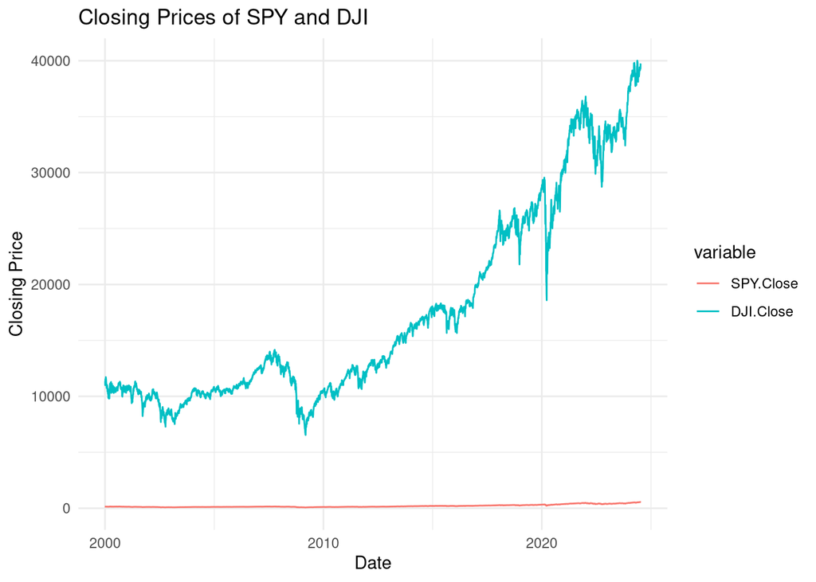

```r
# Load necessary libraries
library(ggplot2)
library(reshape2)

# Combine data into one data frame for plotting
spy_close <- data.frame(Date = index(spy_data), SPY.Close = spy_data$SPY.Close)
dji_close <- data.frame(Date = index(dji_data), DJI.Close = dji_data$DJI.Close)

# Merge data frames by Date
combined_close <- merge(spy_close, dji_close, by = "Date", all = TRUE)

# Melt the data for ggplot2
combined_close_melt <- melt(combined_close, id.vars = "Date")

# Line plot
ggplot(combined_close_melt, aes(x = Date, y = value, color = variable)) +
  geom_line() +
  labs(title = "Closing Prices of SPY and DJI", x = "Date", y = "Closing Price") +
  theme_minimal()
```

## candlestick vizualization

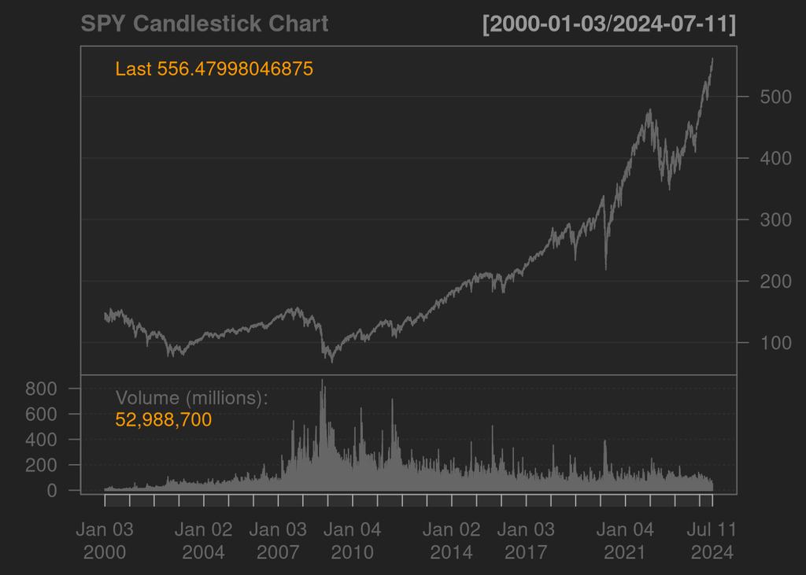

```r
# Load necessary library
library(quantmod)

# Candlestick chart for SPY
chartSeries(spy_data, type = "candlesticks", name = "SPY Candlestick Chart")
```

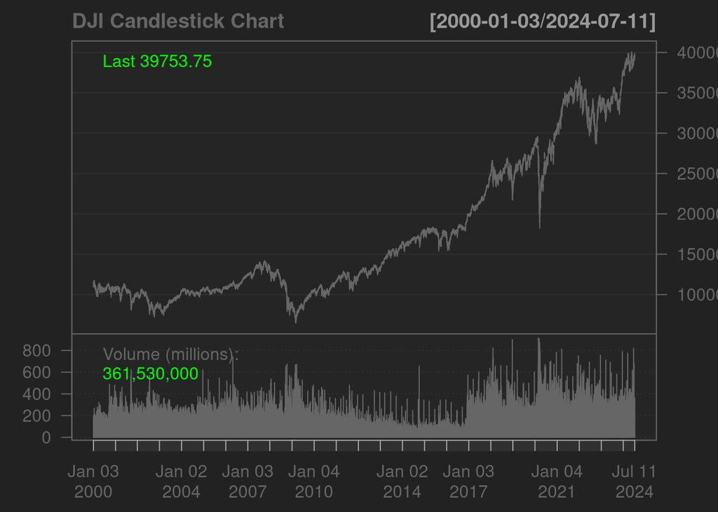

```r
# Candlestick chart for DJI
chartSeries(dji_data, type = "candlesticks", name = "DJI Candlestick Chart")
```

## Volume plot

```
## Defaulting to continuous.
```

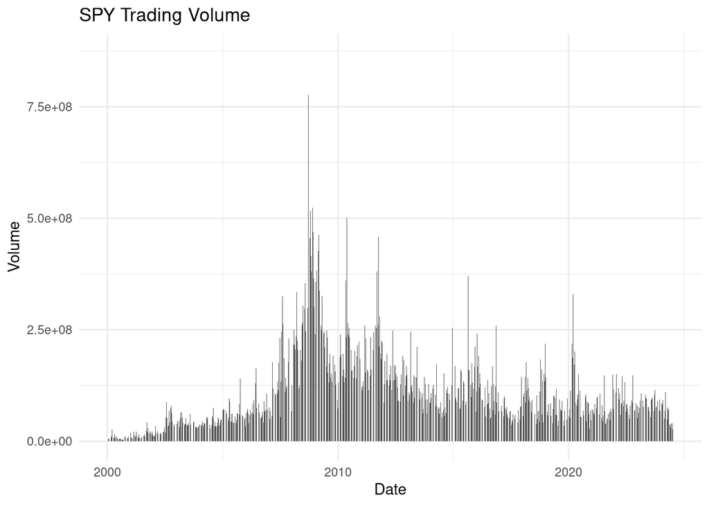

```r
# SPY Volume Plot
ggplot(spy_close, aes(x = Date, y = spy_data$SPY.Volume)) +
  geom_bar(stat = "identity") +
  labs(title = "SPY Trading Volume", x = "Date", y = "Volume") +
  theme_minimal()
```

```
## Defaulting to continuous.
```

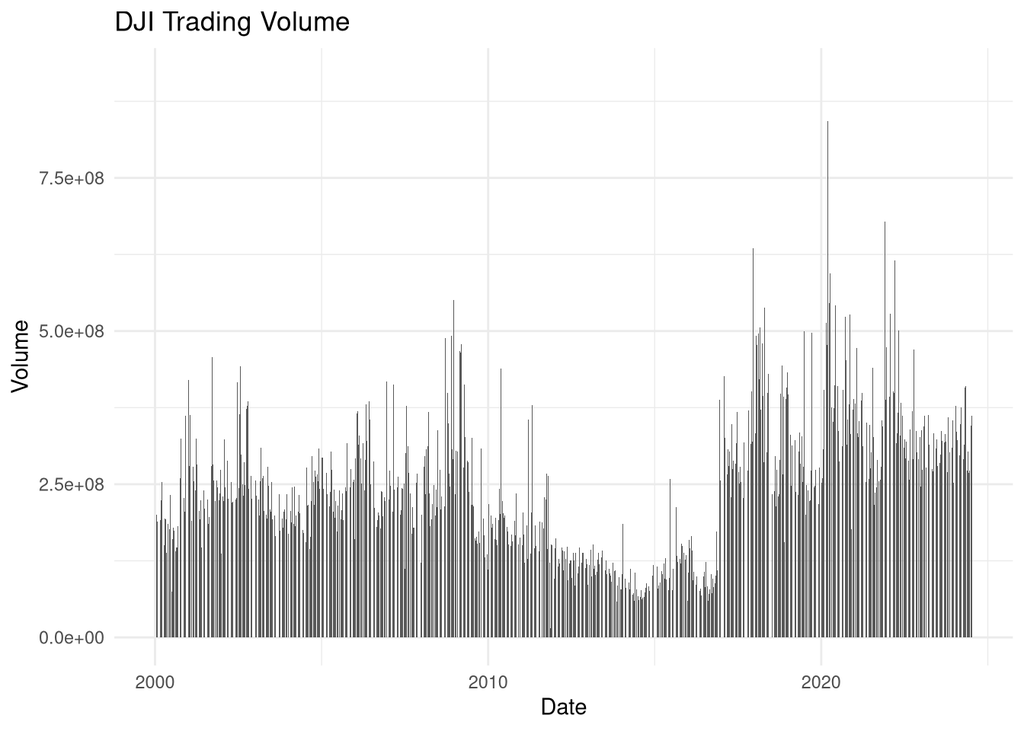

```r
# DJI Volume Plot
ggplot(dji_close, aes(x = Date, y = dji_data$DJI.Volume)) +
  geom_bar(stat = "identity") +
  labs(title = "DJI Trading Volume", x = "Date", y = "Volume") +
  theme_minimal()
```

### Daily returns plot

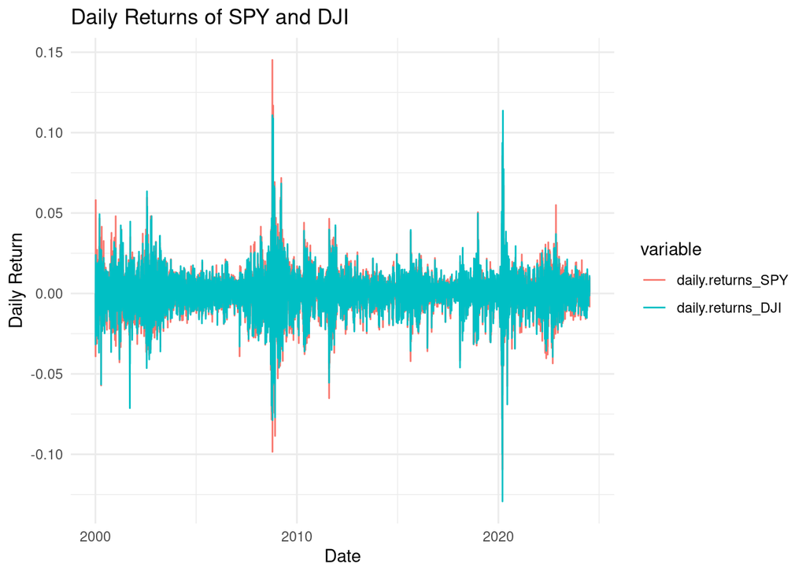

```r
# Calculate daily returns for SPY and DJI
spy_returns <- dailyReturn(spy_data[, "SPY.Adjusted"])
dji_returns <- dailyReturn(dji_data[, "DJI.Adjusted"])

# Convert to data frames
spy_returns_df <- data.frame(Date = index(spy_returns), Return = coredata(spy_returns))
dji_returns_df <- data.frame(Date = index(dji_returns), Return = coredata(dji_returns))

# Combine returns for plotting
combined_returns <- merge(spy_returns_df, dji_returns_df, by = "Date", suffixes = c("_SPY", "_DJI"))
combined_returns_melt <- melt(combined_returns, id.vars = "Date")

# Line plot of daily returns
ggplot(combined_returns_melt, aes(x = Date, y = value, color = variable)) +
  geom_line() +
  labs(title = "Daily Returns of SPY and DJI", x = "Date", y = "Daily Return") +
  theme_minimal()
```

## Moving averages plot

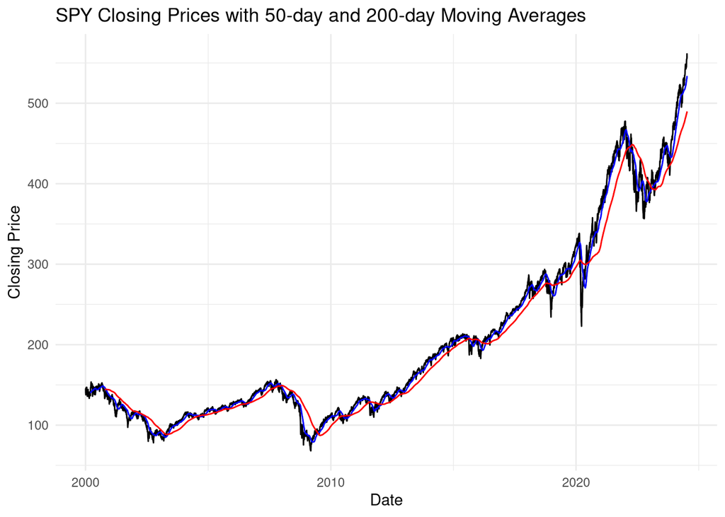

```r
# Calculate 50-day and 200-day moving averages for SPY
spy_data$SPY.MA50 <- SMA(spy_data[, "SPY.Close"], n = 50)
spy_data$SPY.MA200 <- SMA(spy_data[, "SPY.Close"], n = 200)

# Plot SPY with moving averages
ggplot(spy_close, aes(x = Date, y = SPY.Close)) +
  geom_line() +
  geom_line(aes(y = spy_data$SPY.MA50), color = "blue") +
  geom_line(aes(y = spy_data$SPY.MA200), color = "red") +
  labs(title = "SPY Closing Prices with 50-day and 200-day Moving Averages", x = "Date", y = "Closing Price") +
  theme_minimal()
```

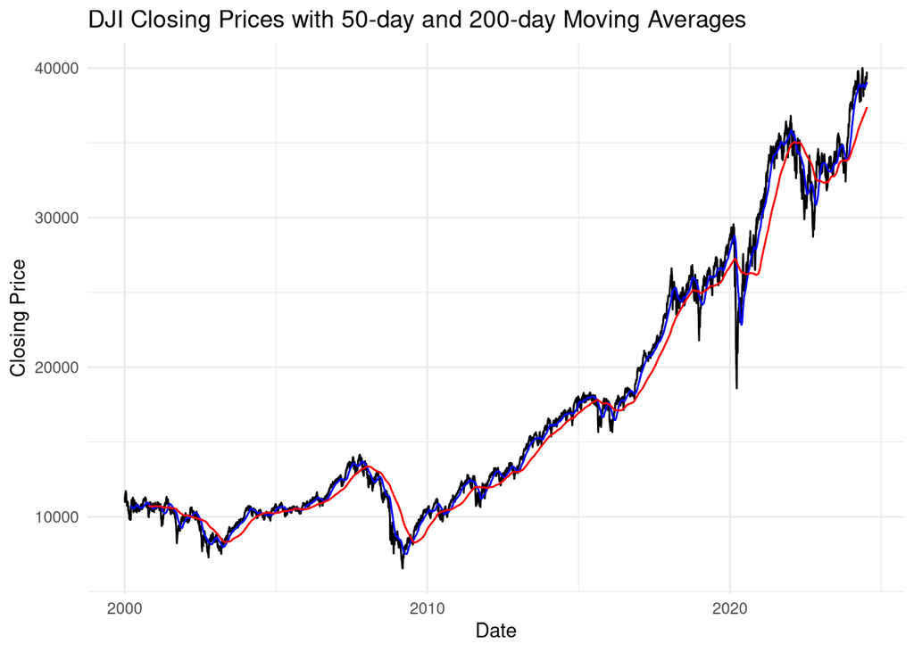

```r
# Calculate 50-day and 200-day moving averages for DJI
dji_data$DJI.MA50 <- SMA(dji_data[, "DJI.Close"], n = 50)
dji_data$DJI.MA200 <- SMA(dji_data[, "DJI.Close"], n = 200)

# Plot DJI with moving averages
ggplot(dji_close, aes(x = Date, y = DJI.Close)) +
  geom_line() +
  geom_line(aes(y = dji_data$DJI.MA50), color = "blue") +
  geom_line(aes(y = dji_data$DJI.MA200), color = "red") +
  labs(title = "DJI Closing Prices with 50-day and 200-day Moving Averages", x = "Date", y = "Closing Price") +
  theme_minimal()
```

### Returns Histogram

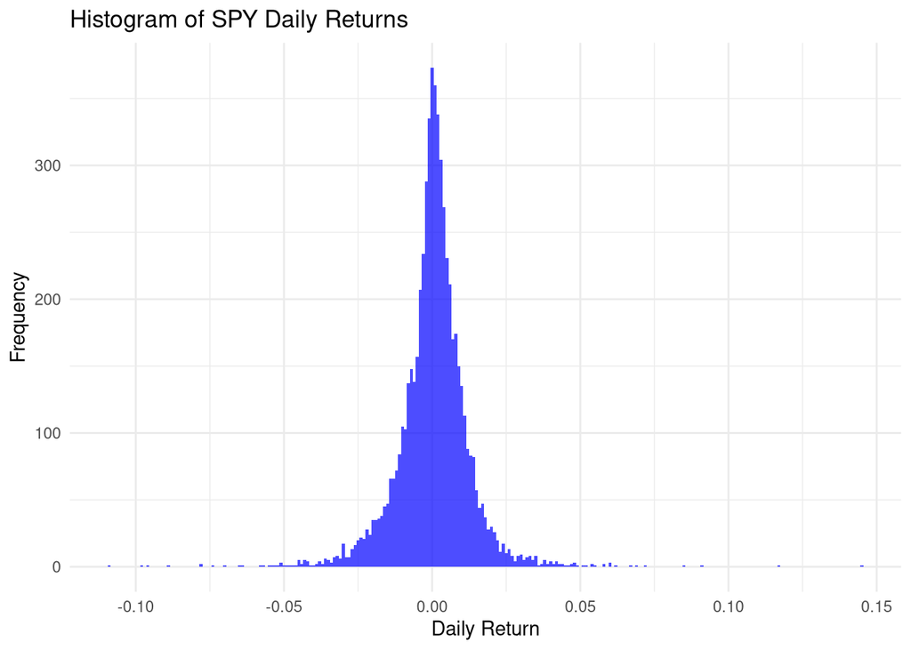

```r
# Histogram of SPY returns
ggplot(spy_returns_df, aes(x = daily.returns)) +
  geom_histogram(binwidth = 0.001, fill = "blue", alpha = 0.7) +
  labs(title = "Histogram of SPY Daily Returns", x = "Daily Return", y = "Frequency") +
  theme_minimal()
```

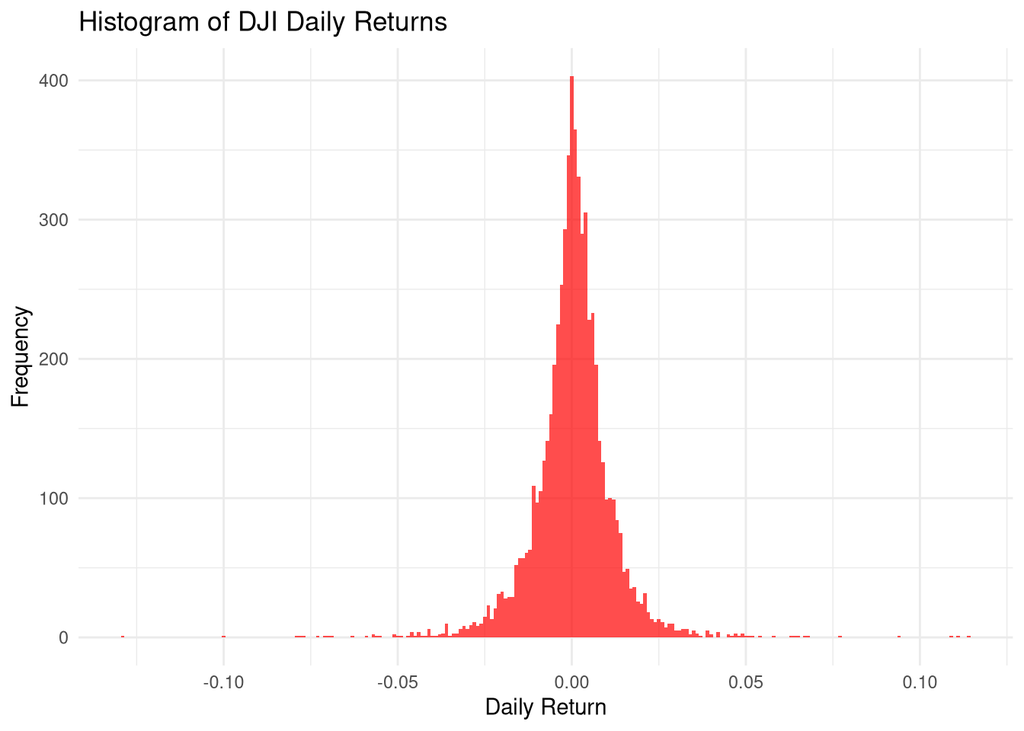

```r
# Histogram of DJI returns
ggplot(dji_returns_df, aes(x = daily.returns)) +
  geom_histogram(binwidth = 0.001, fill = "red", alpha = 0.7) +
  labs(title = "Histogram of DJI Daily Returns", x = "Daily Return", y = "Frequency") +
  theme_minimal()
```